# Coursera Project

MKB

October 23, 2016

Since we want the results to be reproducable

```r
set.seed(4321)
```

Load the test and training data from the files and replacing missing to “NA”.

```r
TrSet <- read.csv("C:/Users/madhura.belani/Dropbox/00-KB/00-Machine Learning/Coursera/Course Project/pml-training.csv", na.strings=c("NA","#DIV/0!", ""))
TstSet <- read.csv("C:/Users/madhura.belani/Dropbox/00-KB/00-Machine Learning/Coursera/Course Project/pml-testing.csv", na.strings=c("NA","#DIV/0!", ""))
```

Checking the data size

```r
dim(TrSet)
```

```
## [1] 19622   160
```

```r
dim(TstSet)
```

```
## [1]  20 160
```

```r
TrSet<-TrSet[,colSums(is.na(TrSet)) == 0]
TstSet <-TstSet[,colSums(is.na(TstSet)) == 0]
```

Checking the data size after cleansing

```r
dim(TrSet)
```

```
## [1] 19622    60
```

```r
dim(TstSet)
```

```
## [1] 20 60
```

Removed 100 empty columns (i.e featuers)

Now removing the unnessessary first 7 columns

```r
 TrSet   <-TrSet[,-c(1:7)]
 TstSet <-TstSet[,-c(1:7)]
```

Checking further to see if we can remove any Near Zero Variables…no variable with nzv=TRUE…so looks like we have finished with pre-processing the Training Set.

```r
nsv <- nearZeroVar(TrSet, saveMetrics = TRUE)
View(nsv)
```

Create a subset of the training data for cross validaion with 75% for training and 25% for validation

```r
SubSamples <- createDataPartition(y=TrSet$classe, p=0.75, list=FALSE)
SubTraining <- TrSet[SubSamples, ]
SubTesting <- TrSet[-SubSamples, ]

dim(SubTraining)
```

```
## [1] 14718    53
```

```r
dim(SubTesting)
```

```
## [1] 4904   53
```

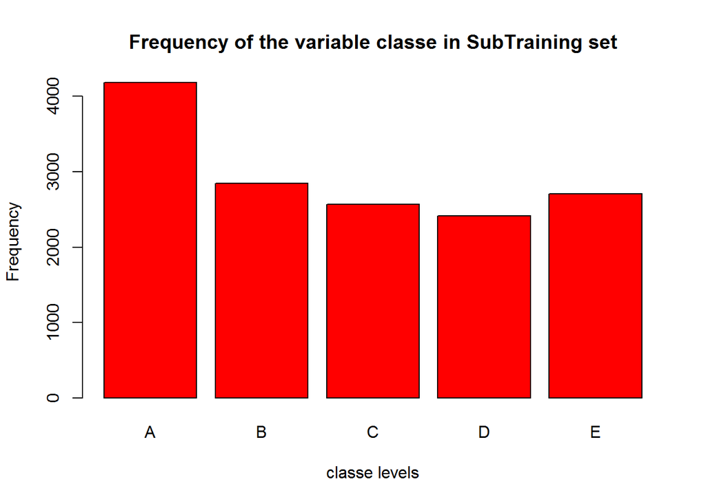

```r
plot(SubTraining$classe, col="red", main="Frequency of the variable classe in SubTraining set", xlab="classe levels", ylab="Frequency")
```

[figure not shown]

```r
plot(SubTraining$classe, col="blue", main="Frequency of the variable classe in SubTesting set", xlab="classe levels", ylab="Frequency")
```

Using the Decision Tree Model create a prediction model on SubTraining and then predict it on SubTesting and plot the decision tree. We can test the accuracy of the prediction on SubTesting using the ConfusionMatrix

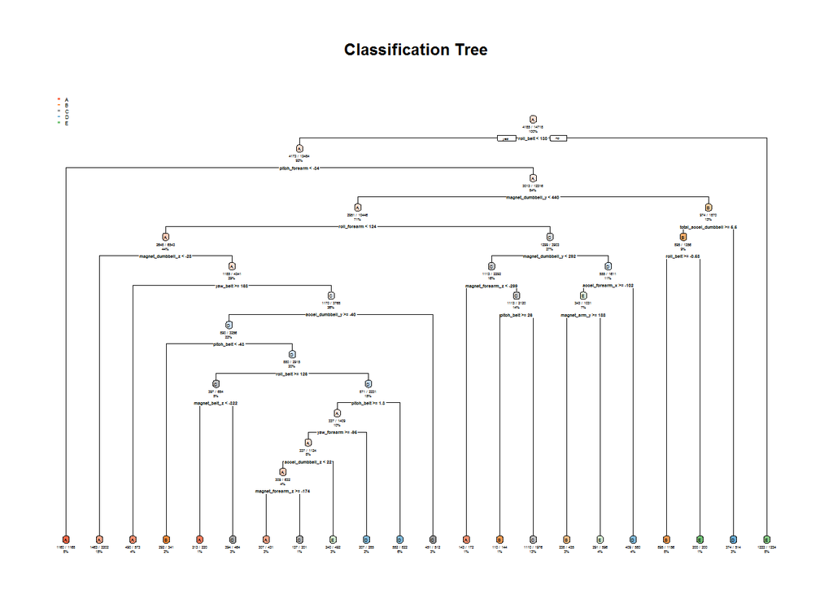

```r
modelDT <- rpart(classe ~ ., data=SubTraining, method="class")
predictionDT <- predict(modelDT, SubTesting, type = "class")
rpart.plot(modelDT, main="Classification Tree", extra=102, under=TRUE, faclen=0)
```

```r
confusionMatrix(predictionDT, SubTesting$classe)
```

```
## Confusion Matrix and Statistics
##
##           Reference
## Prediction    A    B    C    D    E
##          A 1245  195   19   73   27
##          B   29  487   81   24   46
##          C   42   96  680  129  106
##          D   51   80   51  525   51
##          E   28   91   24   53  671
##
## Overall Statistics
##
##                Accuracy : 0.7357
##                  95% CI : (0.7231, 0.748)
##     No Information Rate : 0.2845
##     P-Value [Acc > NIR] : < 2.2e-16
##
##                   Kappa : 0.6646
##  Mcnemar's Test P-Value : < 2.2e-16
##
## Statistics by Class:
##
##                      Class: A Class: B Class: C Class: D Class: E
## Sensitivity            0.8925  0.51317   0.7953   0.6530   0.7447
## Specificity            0.9105  0.95449   0.9079   0.9432   0.9510
## Pos Pred Value         0.7986  0.73013   0.6458   0.6926   0.7739
## Neg Pred Value         0.9552  0.89096   0.9546   0.9327   0.9430
## Prevalence             0.2845  0.19352   0.1743   0.1639   0.1837
## Detection Rate         0.2539  0.09931   0.1387   0.1071   0.1368
## Detection Prevalence   0.3179  0.13601   0.2147   0.1546   0.1768
## Balanced Accuracy      0.9015  0.73383   0.8516   0.7981   0.8479
```

[figure not shown]

```r
fancyRpartPlot((modelDT))
```

Repeat the steps above now using the Random Forest model

```r
modelRF <- randomForest(classe ~. , data=SubTraining, method="class")
predictionRF <- predict(modelRF, SubTesting, type = "class")
confusionMatrix(predictionRF, SubTesting$classe)
```

```
## Confusion Matrix and Statistics
##
##           Reference
## Prediction    A    B    C    D    E
##          A 1394    9    0    0    0
##          B    0  936   12    0    0
##          C    0    4  842   10    0
##          D    0    0    1  793    3
##          E    1    0    0    1  898
##
## Overall Statistics
##
##                Accuracy : 0.9916
##                  95% CI : (0.9887, 0.994)
##     No Information Rate : 0.2845
##     P-Value [Acc > NIR] : < 2.2e-16
##
##                   Kappa : 0.9894
##  Mcnemar's Test P-Value : NA
##
## Statistics by Class:
##
##                      Class: A Class: B Class: C Class: D Class: E
## Sensitivity            0.9993   0.9863   0.9848   0.9863   0.9967
## Specificity            0.9974   0.9970   0.9965   0.9990   0.9995
## Pos Pred Value         0.9936   0.9873   0.9836   0.9950   0.9978
## Neg Pred Value         0.9997   0.9967   0.9968   0.9973   0.9993
## Prevalence             0.2845   0.1935   0.1743   0.1639   0.1837
## Detection Rate         0.2843   0.1909   0.1717   0.1617   0.1831
## Detection Prevalence   0.2861   0.1933   0.1746   0.1625   0.1835
## Balanced Accuracy      0.9984   0.9916   0.9907   0.9927   0.9981
```

Repeat the steps above now using the Gradient Boosting Model. Commented the code as it takes a long time to run!

```r
# modelGBM <- train(classe ~ ., data=SubTraining, method="gbm", verbose=FALSE)
# predictionGBM <- predict(modelGBM, SubTesting, type = "raw")
# confusionMatrix(predictionGBM, SubTesting$classe)
```

Repeat the steps above now using the Linear Discrminate Analysis

```r
modelLDA <- train(classe ~ ., data=SubTraining, method="lda", verbose=FALSE)
predictionLDA <- predict(modelLDA, SubTesting, type = "raw")
confusionMatrix(predictionLDA, SubTesting$classe)
```

```
## Confusion Matrix and Statistics
##
##           Reference
## Prediction    A    B    C    D    E
##          A 1134  150   79   52   30
##          B   22  604   98   26  154
##          C  129  123  557   99   76
##          D  104   31  106  606   83
##          E    6   41   15   21  558
##
## Overall Statistics
##
##                Accuracy : 0.7053
##                  95% CI : (0.6924, 0.7181)
##     No Information Rate : 0.2845
##     P-Value [Acc > NIR] : < 2.2e-16
##
##                   Kappa : 0.6272
##  Mcnemar's Test P-Value : < 2.2e-16
##
## Statistics by Class:
##
##                      Class: A Class: B Class: C Class: D Class: E
## Sensitivity            0.8129   0.6365   0.6515   0.7537   0.6193
## Specificity            0.9114   0.9241   0.8945   0.9210   0.9793
## Pos Pred Value         0.7848   0.6681   0.5661   0.6516   0.8705
## Neg Pred Value         0.9245   0.9137   0.9240   0.9502   0.9195
## Prevalence             0.2845   0.1935   0.1743   0.1639   0.1837
## Detection Rate         0.2312   0.1232   0.1136   0.1236   0.1138
## Detection Prevalence   0.2947   0.1843   0.2007   0.1896   0.1307
## Balanced Accuracy      0.8621   0.7803   0.7730   0.8374   0.7993
```

Repeat the steps above now using the Naive Bayes Model. Commented the code as it takes a long time to run!

```r
# modelNB <- train(classe ~ ., data=SubTraining, method="nb", verbose=FALSE)
# predictionNB <- predict(modelNB, SubTesting, type = "raw")
# confusionMatrix(predictionNB, SubTesting$classe)
```

Accuracy of Random Forest is the highest so apply the ModelRT to the TstSet to get the prediction.

```r
predictfinal <- predict(modelRF, TstSet, type="class")
predictfinal
```

```
##  1  2  3  4  5  6  7  8  9 10 11 12 13 14 15 16 17 18 19 20
##  B  A  B  A  A  E  D  B  A  A  B  C  B  A  E  E  A  B  B  B
## Levels: A B C D E
```